# Homework 2

Ignacio Landerreche

2023-05-21

# 1 Mass shootings in the US

In July 2012, in the aftermath of a mass shooting in a movie theater in Aurora, Colorado, [Mother Jones](https://www.motherjones.com/politics/2012/07/mass-shootings-map/) published a report on mass shootings in the United States since 1982. Importantly, they provided the underlying data set as [an open-source database](https://www.motherjones.com/politics/2012/12/mass-shootings-mother-jones-full-data/) for anyone interested in studying and understanding this criminal behavior.

## 1.1 Obtain the data

| column(variable) | description |
| --- | --- |
| case | short name of incident |
| year, month, day | year, month, day in which the shooting occurred |
| location | city and state where the shooting occcurred |
| summary | brief description of the incident |
| fatalities | Number of fatalities in the incident, excluding the shooter |
| injured | Number of injured, non-fatal victims in the incident, excluding the shooter |
| total_victims | number of total victims in the incident, excluding the shooter |
| location_type | generic location in which the shooting took place |
| male | logical value, indicating whether the shooter was male |
| age_of_shooter | age of the shooter when the incident occured |
| race | race of the shooter |
| prior_mental_illness | did the shooter show evidence of mental illness prior to the incident? |

## 1.2 Explore the data

### 1.2.1 Specific questions

- Generate a data frame that summarizes the number of mass shootings per year.

```r
mass_shootings %>%
  count(year)
```

```
## # A tibble: 37 x 2
##     year     n
##    <dbl> <int>
##  1  1982     1
##  2  1984     2
##  3  1986     1
##  4  1987     1
##  5  1988     1
##  6  1989     2
##  7  1990     1
##  8  1991     3
##  9  1992     2
## 10  1993     4
## # i 27 more rows
```

- Generate a bar chart that identifies the number of mass shooters associated with each race category. The bars should be sorted from highest to lowest and each bar should show its number.

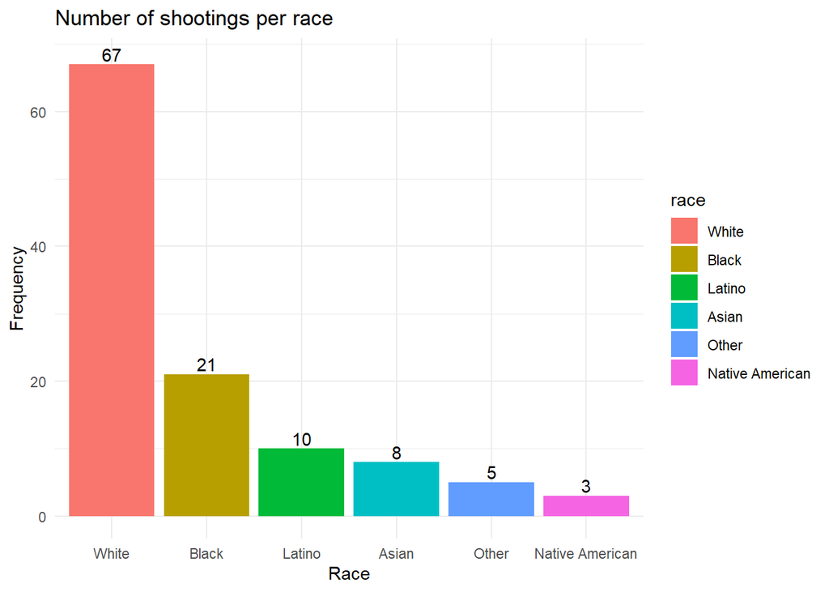

```r
mass_shootings %>%
 count(race,sort=TRUE) %>%
 drop_na(race)%>% #we don't want to have NA's for this variable
  mutate(race=fct_rev(fct_reorder(race,n))) %>% #reordering so in the graph it seems increaseing
  ggplot(aes(race,n,fill=race))+ #aesthetics
  geom_col()+
  geom_text(aes(label = n,y=n+0.5),colour = "black",position=position_dodge(0.9),vjust=0)+
  labs(
    title = "Number of shootings per race",
    x = "Race",
    y = "Frequency"
  )+theme_minimal()
```

- Generate a boxplot visualizing the number of total victims, by type of location.

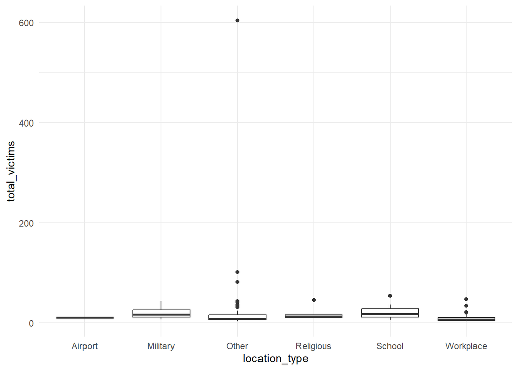

```r
  ggplot(mass_shootings,aes(x=location_type,y=total_victims))+geom_boxplot()+theme_minimal() #very simple and self-explanatory code
```

- Redraw the same plot, but remove the Las Vegas Strip massacre from the dataset.

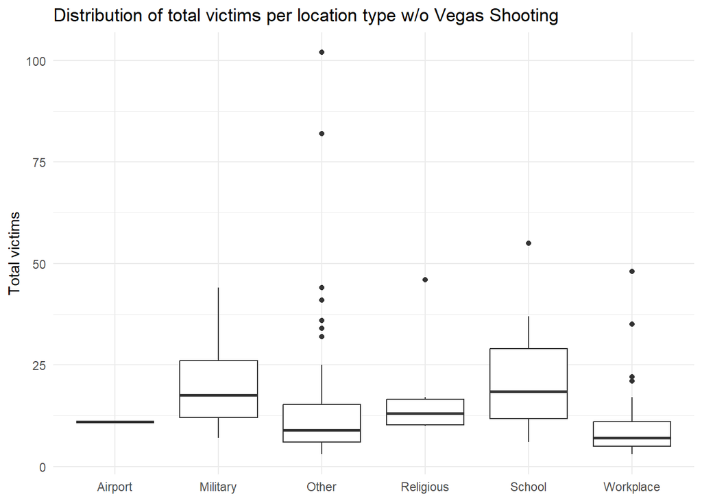

```r
set_woVegas<-mass_shootings %>% filter(location!="Las Vegas, Nevada")
ggplot(set_woVegas,aes(x=location_type,y=total_victims))+geom_boxplot()+theme_minimal()+
  labs(
    title="Distribution of total victims per location type w/o Vegas Shooting",
    y="Total victims",
    x=NULL
  )
```

### 1.2.2 More open-ended questions

Address the following questions. Generate appropriate figures/tables to support your conclusions.

- How many white males with prior signs of mental illness initiated a mass shooting after 2000?

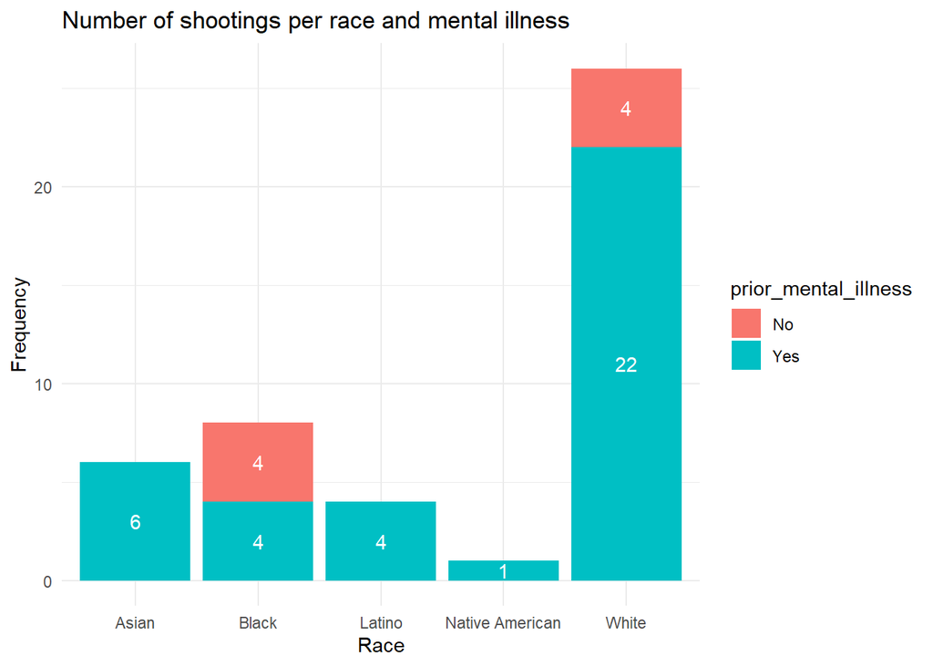

```r
mass_shootings %>%
  filter(male==TRUE, year>2000) %>%  #Filtering after year 2000
  drop_na(race,prior_mental_illness) %>%  #Deleting the NA's from the variables we want
  group_by(race) %>%
  count(prior_mental_illness) %>%
  ggplot(aes(x=race,y=n,fill=prior_mental_illness))+geom_col()+theme_minimal()+
  geom_text(position=position_stack(vjust=0.5),aes(label = n),colour = "white")+
  labs(
    title = "Number of shootings per race and mental illness",
    x = "Race",
    y = "Frequency"
  )
```

- Which month of the year has the most mass shootings? Generate a bar chart sorted in chronological (natural) order (Jan-Feb-Mar- etc) to provide evidence of your answer.

*Answer*: February with 13 shootings

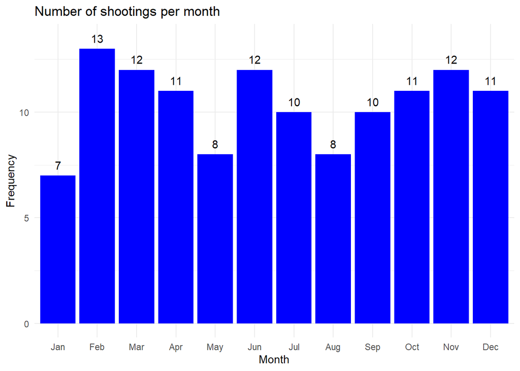

```r
mass_shootings$month2<-factor(mass_shootings$month, levels=c("Jan","Feb","Mar", "Apr", "May", "Jun", "Jul","Aug", "Sep", "Oct", "Nov", "Dec")) #Creating levels and factors from the months already mentioned

mass_shootings %>%
 count(month2) %>%
  ggplot(aes(x=month2,y=n))+geom_col(fill="blue")+theme_minimal()+
labs(
    title = "Number of shootings per month",
    x = "Month",
    y = "Frequency"
  )+geom_text(aes(label = n,y=n+0.5),colour = "black")
```

- How does the distribution of mass shooting fatalities differ between White and Black shooters? What about White and Latino shooters?

*Answer*: one can see that the one with most outliers and biggest IQR is White, then Black and finally Latinos. From the histograms, there is a more visual representation of the total victims among these races.

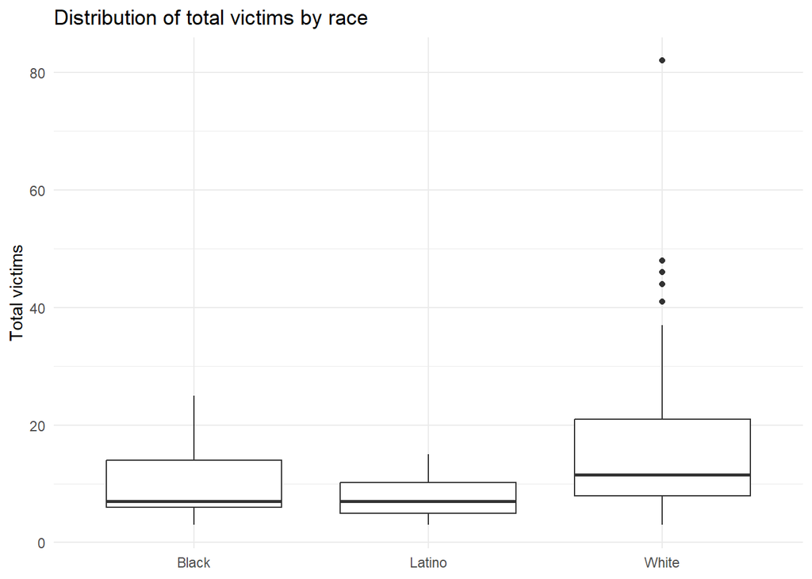

```r
#We want to use the data set without the Vegas distribution which is clearly an outlier
#Creating a boxplot to see distribution, IQR and outliers
set_woVegas %>%
  drop_na(race) %>% #Dropping NA's
  filter(race %in% c("Black","White","Latino")) %>% #Keeping only the races we want to analyze
ggplot(aes(x=race,y=total_victims))+geom_boxplot()+theme_minimal()+
  labs(
    title="Distribution of total victims by race",
    y="Total victims",
    x=NULL
  )
```

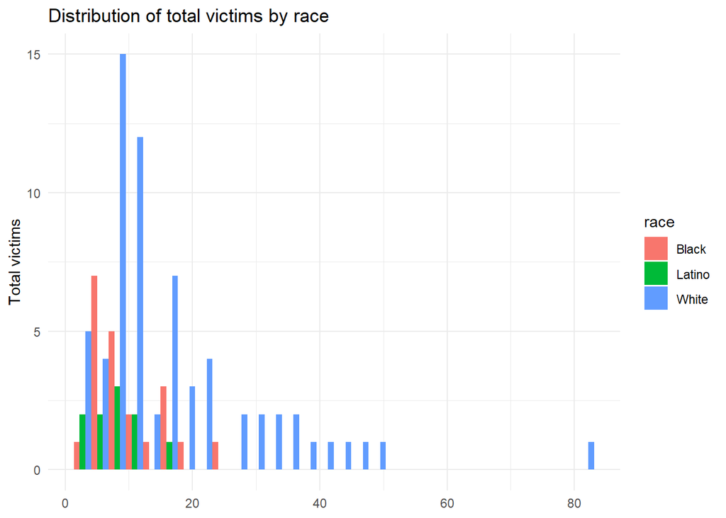

```r
#Creating a bar plot stacked

set_woVegas %>%
  drop_na(race,total_victims) %>%
  filter(race %in% c("Black","White","Latino")) %>%
ggplot(aes(fill=race,x=total_victims))+geom_histogram(position="dodge")+theme_minimal()+
  labs(
    title="Distribution of total victims by race",
    y="Total victims",
    x=NULL
  )
```

### 1.2.3 Very open-ended

- Are mass shootings with shooters suffering from mental illness different from mass shootings with no signs of mental illness in the shooter?

```r
#Analyzing via table
set_woVegas %>%
  group_by(prior_mental_illness) %>%
  drop_na(prior_mental_illness) %>%
  summarise(mean_fatalities=mean(fatalities),mean_injured=mean(injured),mean_victims=mean(total_victims),
                                                                                          mean_age=mean(age_of_shooter))
```

```
## # A tibble: 2 x 5
##   prior_mental_illness mean_fatalities mean_injured mean_victims mean_age
##   <chr>                          <dbl>        <dbl>        <dbl>    <dbl>
## 1 No                              7.06         4.76         11.8     36.8
## 2 Yes                             8.11         8.44         16.5     34.0
```

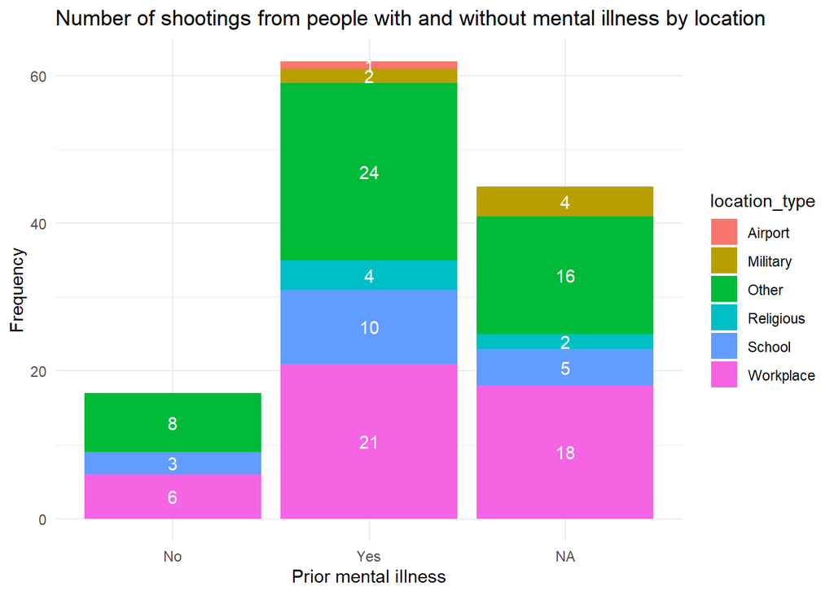

```r
#Analysing by type of place- total
set_woVegas %>%
  group_by(prior_mental_illness) %>%
  #drop_na(prior_mental_illness) %>%
  count(location_type) %>%
  ggplot(aes(x=prior_mental_illness,y=n,fill=location_type))+geom_col()+theme_minimal()+
  geom_text(position=position_stack(vjust=0.5),aes(label = n),colour = "white")+
  labs(
    title = "Number of shootings from people with and without mental illness by location",
    x = "Prior mental illness",
    y = "Frequency"
  )
```

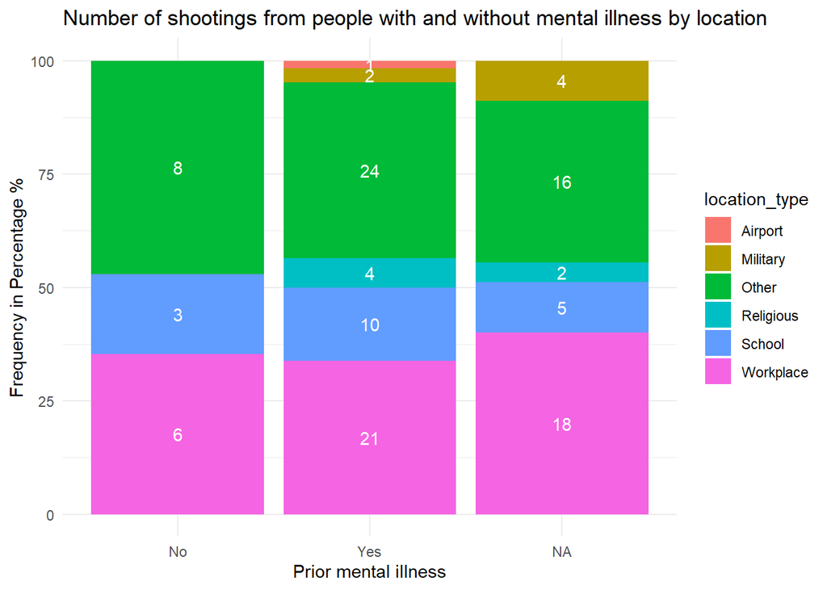

```r
#Analysing by type of place- frequency /percentage of total
set_woVegas %>%
  group_by(prior_mental_illness) %>%
  count(location_type) %>%
  mutate(freq=(n/sum(n))*100)%>%
  ggplot(aes(x=prior_mental_illness,y=freq,fill=location_type))+geom_col()+theme_minimal()+
  geom_text(position=position_stack(vjust=0.5),aes(label = n),colour = "white")+
  labs(
    title = "Number of shootings from people with and without mental illness by location",
    x = "Prior mental illness",
    y = "Frequency in Percentage %"
  )
```

- Assess the relationship between mental illness and total victims, mental illness and location type, and the intersection of all three variables.

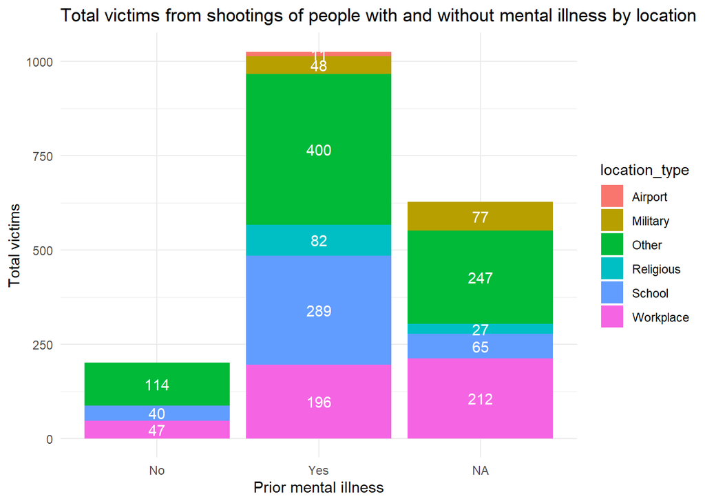

```r
set_woVegas %>%
  group_by(prior_mental_illness,location_type) %>%
  drop_na(location_type) %>%
  summarise(count=n(),total_victims=sum(total_victims)) %>%
  ggplot(aes(x=prior_mental_illness,y=total_victims,fill=location_type))+geom_col()+theme_minimal()+
  geom_text(position=position_stack(vjust=0.5),aes(label = total_victims),colour = "white")+
  labs(
    title = "Total victims from shootings of people with and without mental illness by location",
    x = "Prior mental illness",
    y = "Total victims"
  )
```

# 2 Exploring credit card fraud

We will be using a dataset with credit card transactions containing legitimate and fraud transactions. Fraud is typically well below 1% of all transactions, so a naive model that predicts that all transactions are legitimate and not fraudulent would have an accuracy of well over 99%– pretty good, no? (well, not quite as we will see later in the course)

You can read more on credit card fraud on [Credit Card Fraud Detection Using Weighted Support Vector Machine](https://www.scirp.org/journal/paperinformation.aspx?paperid=105944)

The dataset we will use consists of credit card transactions and it includes information about each transaction including customer details, the merchant and category of purchase, and whether or not the transaction was a fraud.

## 2.1 Obtain the data

The dataset is too large to be hosted on Canvas or Github, so please download it from dropbox https://www.dropbox.com/sh/q1yk8mmnbbrzavl/AAAxzRtIhag9Nc_hODafGV2ka?dl=0 and save it in your `dsb` repo, under the `data` folder

The data dictionary is as follows

| column(variable) | description |
| --- | --- |
| trans_date_trans_time | Transaction DateTime |
| trans_year | Transaction year |
| category | category of merchant |
| amt | amount of transaction |
| city | City of card holder |
| state | State of card holder |
| lat | Latitude location of purchase |
| long | Longitude location of purchase |
| city_pop | card holder’s city population |
| job | job of card holder |
| dob | date of birth of card holder |
| merch_lat | Latitude Location of Merchant |
| merch_long | Longitude Location of Merchant |
| is_fraud | Whether Transaction is Fraud (1) or Not (0) |

- In this dataset, how likely are fraudulent transactions? Generate a table that summarizes the number and frequency of fraudulent transactions per year.

```r
card_fraud %>%
  group_by(trans_year,is_fraud) %>%
  summarise(total_trans=n())%>%
  mutate(freq_in_percentage=total_trans/sum(total_trans)*100)#Creating frequency in percentage
```

```
## # A tibble: 4 x 4
## # Groups:   trans_year [2]
##   trans_year is_fraud total_trans freq_in_percentage
##        <dbl>    <dbl>       <int>              <dbl>
## 1       2019        0      475925             99.4
## 2       2019        1        2721              0.568
## 3       2020        0      191167             99.4
## 4       2020        1        1215              0.632
```

- How much money (in US$ terms) are fraudulent transactions costing the company? Generate a table that summarizes the total amount of legitimate and fraudulent transactions per year and calculate the % of fraudulent transactions, in US$ terms.

```r
card_fraud %>%
  group_by(trans_year,is_fraud) %>%
  summarise(total_amount=sum(amt))%>%
  mutate(freq_in_percentage=total_amount/sum(total_amount)*100) #Calculating the frequency in %
```

```
## # A tibble: 4 x 4
## # Groups:   trans_year [2]
##   trans_year is_fraud total_amount freq_in_percentage
##        <dbl>    <dbl>        <dbl>              <dbl>
## 1       2019        0    32182901.              95.8
## 2       2019        1     1423140.               4.23
## 3       2020        0    12925914.              95.2
## 4       2020        1      651949.               4.80
```

- Generate a histogram that shows the distribution of amounts charged to credit card, both for legitimate and fraudulent accounts. Also, for both types of transactions, calculate some quick summary statistics.

```r
#Summary
summary(card_fraud$amt)
```

```
##     Min.  1st Qu.   Median     Mean  3rd Qu.     Max.
##     1.00     9.64    47.41    70.32    83.01 27119.77
```

```r
card_fraud %>%
  group_by(is_fraud) %>%
  summarise(mins=min(amt),means=mean(amt),maxs=max(amt))
```

```
## # A tibble: 2 x 4
##   is_fraud  mins means   maxs
##      <dbl> <dbl> <dbl>  <dbl>
## 1        0  1     67.6 27120.
## 2        1  1.06 527.   1334.
```

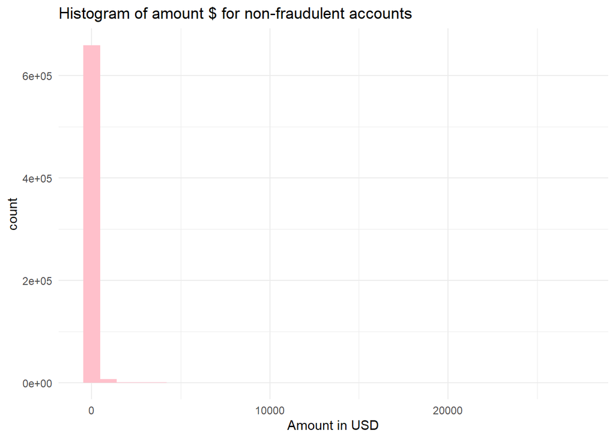

```r
#Histogram for non_fradulent
card_fraud %>%
  filter(is_fraud==0) %>%
  ggplot(aes(x=amt))+geom_histogram(fill="pink")+ labs(
    title="Histogram of amount $ for non-fraudulent accounts",
    y="count",
    x="Amount in USD"

  )+theme_minimal()
```

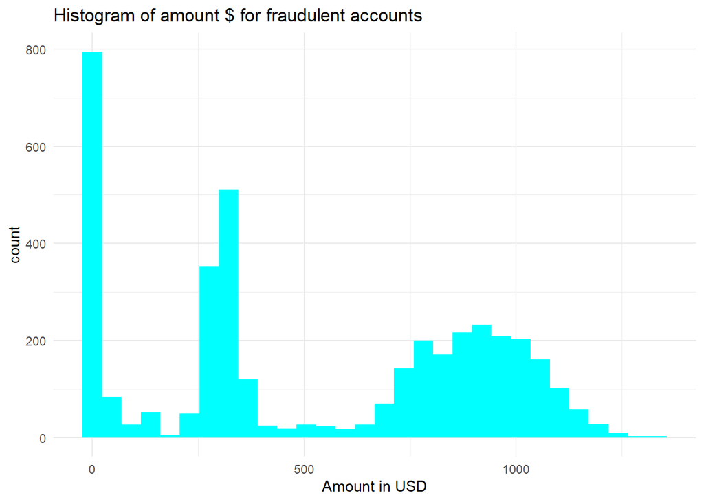

```r
#Histogram for fradulent
card_fraud %>%
  filter(is_fraud==1) %>%
  ggplot(aes(x=amt))+geom_histogram(fill="cyan")+ labs(
    title="Histogram of amount $ for fraudulent accounts",
    y="count",
    x="Amount in USD"

  )+theme_minimal()
```

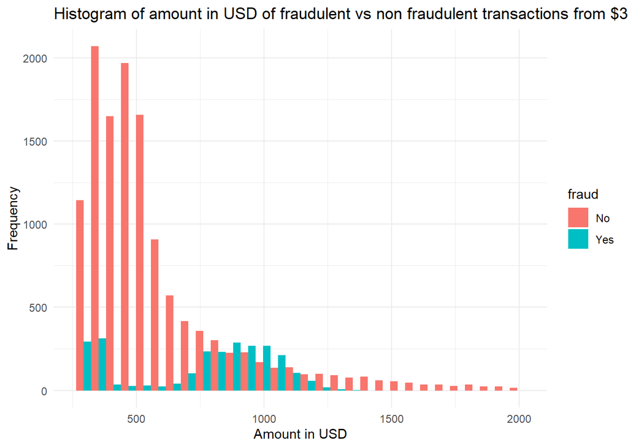

```r
#Histogram of both combined,
#Its seems that amounts are very volatile and depending of fraudulent and non fraudulent, for the histogram I will exclude outliers by randomly using the threshold of 2000 which is a little bit higher than the maximum amount of fraudulent amounts. Also, there are many small amounts of non-fraudulent occurring, so I am using a min threshold of 300, just to see a good representation of distribution among fraudulent and non-fraudulent.

card_fraud %>%
  filter(amt<2000 & amt>300) %>%
  mutate(fraud=ifelse(is_fraud==1,"Yes","No")) %>%
ggplot(aes(x=amt,fill=fraud))+geom_histogram(position="dodge")+theme_minimal()+labs(
  title="Histogram of amount in USD of fraudulent vs non fraudulent transactions from $300-$2000",
  x="Amount in USD",
  y="Frequency"
)
```

- What types of purchases are most likely to be instances of fraud? Consider category of merchants and produce a bar chart that shows % of total fraudulent transactions sorted in order.

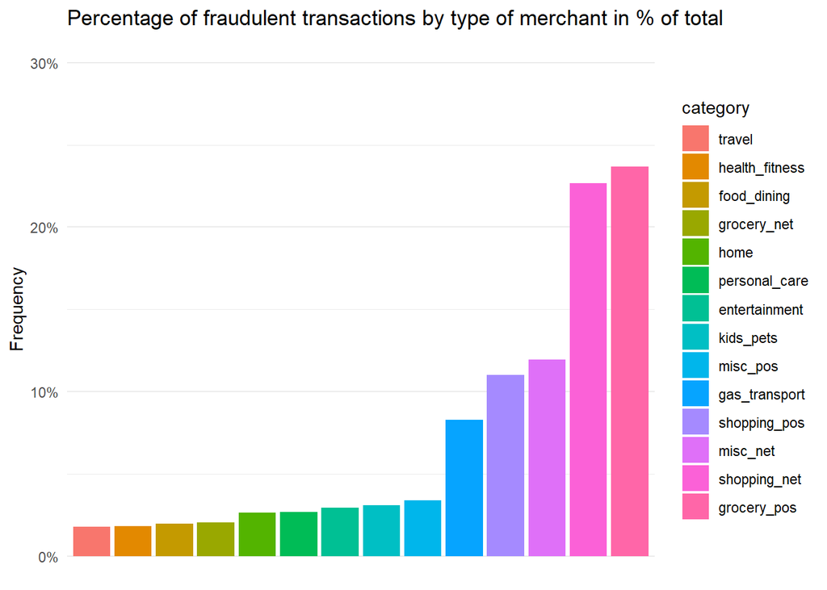

```r
card_fraud %>%
  filter(is_fraud==1) %>%
  count(category) %>%
  mutate(freq=n/sum(n)) %>%  #Calculating frequency
  mutate(category=fct_reorder(category,freq)) %>%  #Rearranging
  ggplot(aes(y=freq,x=category,fill=category))+geom_col()+theme_minimal()+labs(
    title="Percentage of fraudulent transactions by type of merchant in % of total",
    x=NULL,
    y="Frequency"
  )+ scale_x_discrete(labels=NULL, breaks=NULL)+ scale_y_continuous(labels = scales::percent, limits=c(0,0.3))
```

- When is fraud more prevalent? Which days, months, hours? To create new variables to help you in your analysis, we use the `lubridate` package and the following code

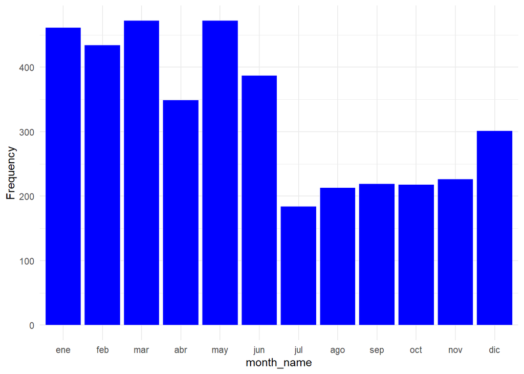

```r
#Creating a function that takes as argument which time (month_name, hour, weekday) and will return the desired graph
hist_time<-function(time){
    card_fraud %>%
    filter(is_fraud==1) %>% #Filtering only for fraud
  mutate(
  date_only = lubridate::date(trans_date_trans_time),
  month_name = lubridate::month(trans_date_trans_time, label=TRUE),
  hour = lubridate::hour(trans_date_trans_time),
  weekday = lubridate::wday(trans_date_trans_time, label = TRUE)
  ) %>%
    count({{time}}) %>%
  ggplot(aes(x={{time}},y=n))+geom_col(fill="blue")+theme_minimal()+labs(
    y="Frequency"
  )

  }
#Evaluating function with month_name
hist_time(month_name)
```

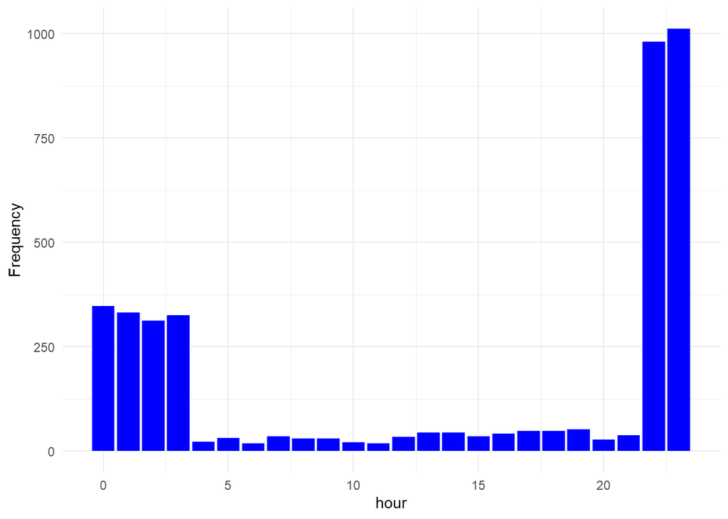

```r
#Evaluating function with hour
hist_time(hour)
```

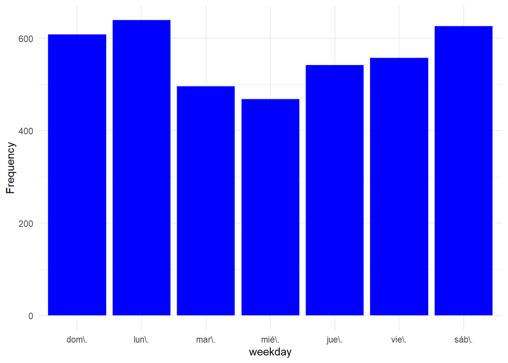

```r
#Evaluating function by weekday
hist_time(weekday)
```

- Are older customers significantly more likely to be victims of credit card fraud? To calculate a customer’s age, we use the `lubridate` package and the following code

```
  mutate(
   age = interval(dob, trans_date_trans_time) / years(1),
    )
```

*Answer*: It looks like the victims of fraudulent transactions were mostly in the age interval of 25-50 (Adults)

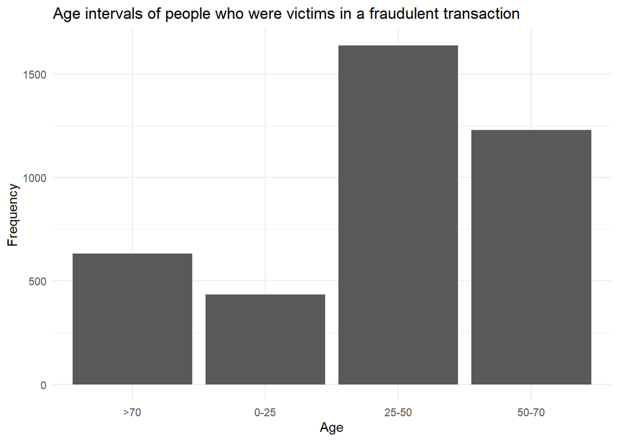

```r
card_fraud %>%
  filter(is_fraud==1) %>%
  mutate(dob2 = dmy(dob))%>%
  mutate(age = round(interval(dob2, trans_date_trans_time)/years(1)),0) %>%
  mutate(age_interval=case_when(
    age<=25~"0-25",
    age<50~"25-50",
    age<70~"50-70",
    .default=">70"
  )) %>%
  count(age_interval) %>%
  ggplot(aes(x=age_interval,y=n))+geom_col()+theme_minimal()+labs(
    title="Age intervals of people who were victims in a fraudulent transaction",
    x="Age",
    y="Frequency"
  )
```

- Is fraud related to distance? The distance between a card holder’s home and the location of the transaction can be a feature that is related to fraud. To calculate distance, we need the latidue/longitude of card holders’s home and the latitude/longitude of the transaction, and we will use the [Haversine formula](https://en.wikipedia.org/wiki/Haversine_formula) to calculate distance. I adapted code to [calculate distance between two points on earth](https://www.geeksforgeeks.org/program-distance-two-points-earth/amp/) which you can find below

```r
# distance between card holder's home and transaction
# code adapted from https://www.geeksforgeeks.org/program-distance-two-points-earth/amp/


card_fraud <- card_fraud %>%
  mutate(

    # convert latitude/longitude to radians
    lat1_radians = lat / 57.29577951,
    lat2_radians = merch_lat / 57.29577951,
    long1_radians = long / 57.29577951,
    long2_radians = merch_long / 57.29577951,

    # calculate distance in miles
    distance_miles = 3963.0 * acos((sin(lat1_radians) * sin(lat2_radians)) + cos(lat1_radians) * cos(lat2_radians) * cos(long2_radians - long1_radians)),

    # calculate distance in km
    distance_km = 6377.830272 * acos((sin(lat1_radians) * sin(lat2_radians)) + cos(lat1_radians) * cos(lat2_radians) * cos(long2_radians - long1_radians))

  )
```

Plot a boxplot or a violin plot that looks at the relationship of distance and `is_fraud`. Does distance seem to be a useful feature in explaining fraud?

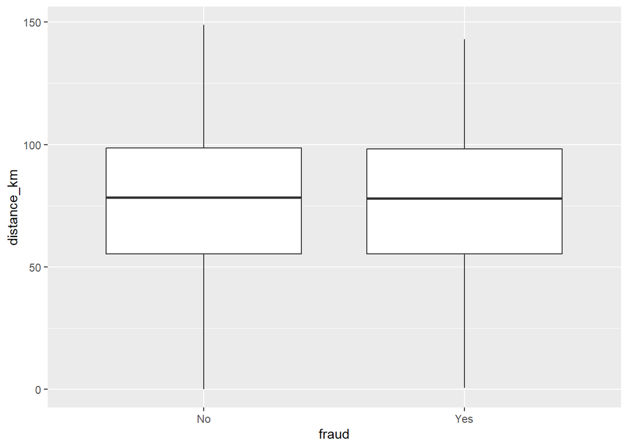

```r
card_fraud %>%
  mutate(fraud=ifelse(is_fraud==1,"Yes","No")) %>%
ggplot(aes(x=fraud,y=distance_km))+geom_boxplot()
```

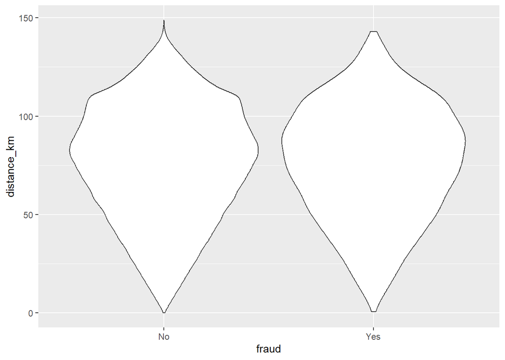

```r
card_fraud %>%
  mutate(fraud=ifelse(is_fraud==1,"Yes","No")) %>%
ggplot(aes(x=fraud,y=distance_km))+geom_violin()
```

-Answer_ It doesn’t seem like fraud is related to distance!!

# 3 Exploring sources of electricity production, CO2 emissions, and GDP per capita.

There are many sources of data on how countries generate their electricity and their CO2 emissions. I would like you to create three graphs:

## 3.1 1. A stacked area chart that shows how your own country generated its electricity since 2000.

You will use

`geom_area(colour="grey90", alpha = 0.5, position = "fill")`

## 3.2 2. A scatter plot that looks at how CO2 per capita and GDP per capita are related

## 3.3 3. A scatter plot that looks at how electricity usage (kWh) per capita/day GDP per capita are related

We will get energy data from the Our World in Data website, and CO2 and GDP per capita emissions from the World Bank, using the `wbstats`package.

```r
# Download electricity data
url <- "https://nyc3.digitaloceanspaces.com/owid-public/data/energy/owid-energy-data.csv"

energy <- read_csv(url) %>%
  filter(year >= 1990) %>%
  drop_na(iso_code) %>%
  select(1:3,
         biofuel = biofuel_electricity,
         coal = coal_electricity,
         gas = gas_electricity,
         hydro = hydro_electricity,
         nuclear = nuclear_electricity,
         oil = oil_electricity,
         other_renewable = other_renewable_exc_biofuel_electricity,
         solar = solar_electricity,
         wind = wind_electricity,
         electricity_demand,
         electricity_generation,
         net_elec_imports,  # Net electricity imports, measured in terawatt-hours
         energy_per_capita, # Primary energy consumption per capita, measured in kilowatt-hours Calculated by Our World in Data based on BP Statistical Review of World Energy and EIA International Energy Data
         energy_per_gdp,    # Energy consumption per unit of GDP. This is measured in kilowatt-hours per 2011 international-$.
         per_capita_electricity, #  Electricity generation per capita, measured in kilowatt-hours
  )

# Download data for C02 emissions per capita https://data.worldbank.org/indicator/EN.ATM.CO2E.PC
co2_percap <- wb_data(country = "countries_only",
                      indicator = "EN.ATM.CO2E.PC",
                      start_date = 1990,
                      end_date = 2022,
                      return_wide=FALSE) %>%
  filter(!is.na(value)) %>%
  #drop unwanted variables
  select(-c(unit, obs_status, footnote, last_updated)) %>%
  rename(year = date,
         co2percap = value)


# Download data for GDP per capita  https://data.worldbank.org/indicator/NY.GDP.PCAP.PP.KD
gdp_percap <- wb_data(country = "countries_only",
                      indicator = "NY.GDP.PCAP.PP.KD",
                      start_date = 1990,
                      end_date = 2022,
                      return_wide=FALSE) %>%
  filter(!is.na(value)) %>%
  #drop unwanted variables
  select(-c(unit, obs_status, footnote, last_updated)) %>%
  rename(year = date,
         GDPpercap = value)
```

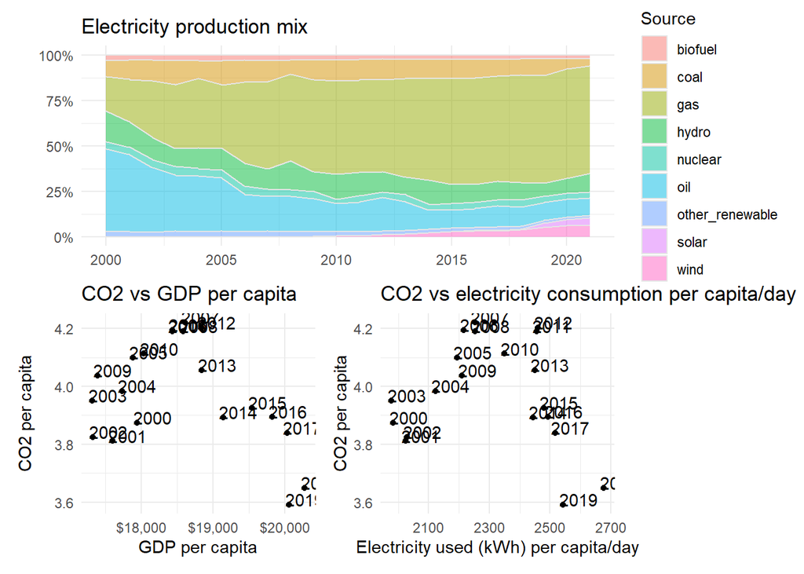

```r
#Changing data  to long table
type_energy<-energy %>%
  select(-c(electricity_demand,electricity_generation,net_elec_imports,energy_per_capita,energy_per_gdp,per_capita_electricity)) %>%
  pivot_longer(cols=4:12, names_to="Source",values_to="Values")


#Joining tables to generate second and third chart
#Modifying country name to ISO3 for first table
first_table<-energy %>%
  filter(year>=2000) %>%
  select(c(country,year,electricity_demand,electricity_generation,net_elec_imports,energy_per_capita,energy_per_gdp,per_capita_electricity)) %>%
  mutate(country=ifelse(country=="Turkiye","Turkey",country)) %>%
  mutate(iso=countrycode(country,"country.name",destination="iso3c"))
#Modifying country names to ISO3 for second table
gdp_percap2<-gdp_percap %>%
  filter(year>=2000) %>%
  select(country,year,GDPpercap) %>%
  mutate(country=ifelse(country=="Turkiye","Turkey",country)) %>%
  mutate(iso=countrycode(country,"country.name",destination="iso3c"))%>%
  select(-country)
#Modifying country name to ISO 3 for third table
co2_percap2<-co2_percap %>%
  filter(year>=2000) %>%
  select(country,year,co2percap) %>%
  mutate(country=ifelse(country=="Turkiye","Turkey",country)) %>%
  mutate(iso=countrycode(country,"country.name",destination="iso3c")) %>%
  select(-country)

#Left joining the three tables above modified by the ISO variable

final_table<- first_table %>%
  left_join(gdp_percap2,by=c("year"="year","iso"="iso")) %>%
  left_join(co2_percap2,by=c("year"="year","iso"="iso"))

#Function for 3 graphs- NOTE: the country needs to be in ISO3 format

three_graphs<-function(country){

# First Graph
g1<-type_energy %>%
  filter(iso_code=={{country}},year>=2000)%>%
  ggplot(aes(x=year,y=Values,fill=Source))+geom_area(colour="grey90",alpha = 0.5, position = "fill")+scale_y_continuous(labels = scales::percent)+theme_minimal()+labs(
    title="Electricity production mix",
    y=NULL,
    x=NULL
  )

#second graph
g2<-final_table %>%
  filter(iso=={{country}},year>=2000) %>%
  ggplot(aes(x=GDPpercap,y=co2percap,label=year))+geom_point()+geom_text(hjust=0.1, vjust=0.1)+theme_minimal()+labs(
    title="CO2 vs GDP per capita",
    x="GDP per capita",
    y= "CO2 per capita"
  )+scale_x_continuous(labels=scales::dollar_format())

#Third Grahp
g3<-final_table %>%
  filter(iso=={{country}},year>=2000) %>%
  ggplot(aes(y=co2percap,x=per_capita_electricity,label=year))+geom_point()+geom_text(hjust=0.1, vjust=0.1)+theme_minimal()+labs(
    title="CO2 vs electricity consumption per capita/day",
    y="CO2 per capita",
    x= "Electricity used (kWh) per capita/day"
  )
(g1/(g2|g3)) #Output using patchwork
}

#Evaluating function on my country <3
three_graphs("MEX")
```

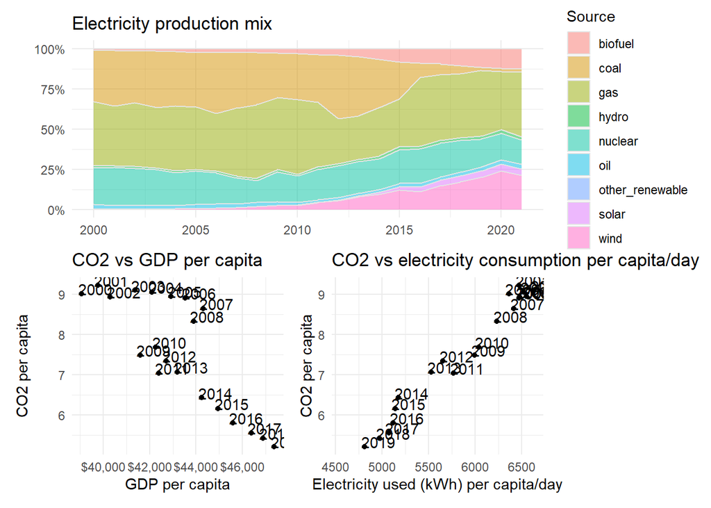

```r
#Evaluating graph on the country I am living currently
three_graphs("GBR")
```

# 4 Details

- Who did you collaborate with: Only wiht myself
- Approximately how much time did you spend on this problem set: Around 5 hours
- What, if anything, gave you the most trouble: Labels and calculating frequencies